# Кластеризация

Roman Menyalschikov

04 11 2020

#### Гипотеза:

Построение кривых Лоренца и расчет индекса Джинни для различных показателей сахароносных культур показало, что их производство сосредоточено в небольшом количестве стран, поэтому нашу совокупность можно разделить, в первую очередь, на два больших кластера - это основные производители и все остальные.

В этой работе мы попытаемся выделить кластеры стран на основе построения диаграмма рассеяния, проведения кластеризации методами к-среднего и иерархической кластеризации. И таких основных показателей как валовой сбор, площадь посевов, урожайность, площадь сельско-хозяйственных земель. Так как каждая величина имеет свои единицы измерения, то все показатели необходимо будет нормировать.

#### Методика:

*Кластеризация (или кластерный анализ)* — это задача разбиения множества объектов на группы, называемые кластерами. Внутри каждой группы должны оказаться «похожие» объекты, а объекты разных группы должны быть как можно более отличны. Главное отличие кластеризации от классификации состоит в том, что перечень групп четко не задан и определяется в процессе работы алгоритма.

Вхождение объектов в ту или иную группу/кластер опредлеяется с помощью вычесления расстояния между ними. Существует большое количество расстояний:

- Евклидово расстояние и его квадрта
- Манхэттенское расстояние (расстояние городских кварталов)
- Расстояние Чебышева
- Степенное расстояние

Чаще всего используется Евклидово расстояние:

$$d_ij = \sqrt{\sum_{k=1}^m (x_{ik} - x_{jk})^2}$$
Или его квадрта:

$$d_ij = \sum_{k=1}^m (x_{ik} - x_{jk})^2$$

Работа 2.1 подразумевает визуальное разделение на кластеры по диаграмме рассеивания и вычисление полученных центроидов класетров. В работе 2.2 используются алгоритмы к-среднего и иерархической кластеризации.

**Алгоритм k-средних (k-meams)** стремится минимизировать суммарное квадратичное отклонение точек кластеров от центров этих кластеров. Идея метода заключается в следующем:

1. Заранее определяем исходное количество кластеров, на которые будут поделеные данные в итоге
2. Случайно выбираются начальные позиции центроидов кластера
3. Для каждого наблюдения определяется к какому центроиду он ближе всего
4. Далее происходит смещение позиций центроидов
5. Снова для каждого наблюдения определяется к какому центроиду он ближе
6. Если принадлежность некоторых точек сменилось, то алгоритм повторяется, а если нет, то кластреный анализ сошелся

**Иерархическая класетризация** - метод разделения объектов на группы с использованием дендограммы. Наиболее часто используется метод *одиночной связи или ближнего соседа* для нахождения расстояния между единицами совокупности. Верх дендограммы (ствол) соотвествует всем измерениям, а низ (листья) - одно наблюдение - один кластре. Данный метод свободен от априорного предположения о количестве кластеров.

#### Эмпирика:

Проведем для начала визуальное деление нашей совокупности на кластеры. На рисунке 1 изображен диаграмма рассеяния для сахарной свеклы с выделенными кластерами. Всего было выделено 3 кластера стран, наблюдение для РФ является выбросом. В таблице ниже представлены координаты получившихся кластеров.

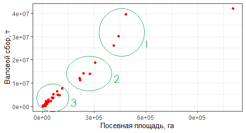

Рис. 1 Диаграмма рассеяния с выделенными кластерами для сахарной свеклы

[output not shown]

На рисунке 2 представлена диаграмма рассеяния для сахарного тростника. Видно, что основная часть наблюдений сосредоточена в левом нижнем углу. Наблюдения для Бразилии и Индии являются выбросами. Удалим их из нашего анализа.

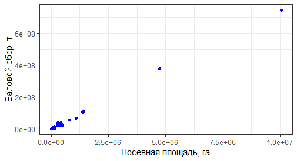

Рис. 2 Диаграмма рассеяния для сахарного тростника

На рисунке 3 четко выделяются 4 кластера. В таблице ниже перечислены координатых центроидов для каждого кластера.

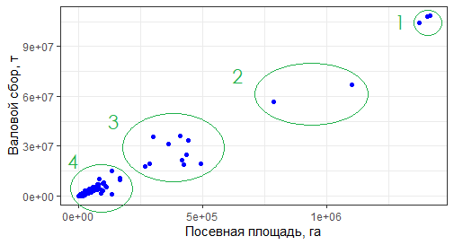

Рис. 3 Диаграмма рассеяния с выделенными кластерами для сахарного тростника

```
  Номер.кластера Координата.X.центроида Координата.Y.центроида
1              1                1300000                1.0e+08
2              2                 900000                6.0e+07
3              3                 300000                2.9e+07
4              4                 100000                1.0e+07
```

Отдельно выделяются Бразилия и Индия, которые являются *абсолютными лидерами* среди всех стран. В первую группу входят *страны-лидеры* - это Китай, Таиланд, со среденими показателями: 100 млн т - валовой сбор и 1.3 млн га - посевная площадь. Кластер №2 соотвествует двум наблюдениям - это Пакистан и Мексика. Это *крупные-производители*, со средними показателями равными 60 млн т (валовой сбор) и 900 тыс. га (посевная площадь). Третий кластер соотвествует уже более большой группе *стран со средними показателями производства* сахарного тростника. В него входят - Колумбия, Гватемала, Автстралия, США и др. (валовой сбор - 30 млн т, посевная площадь - 300 тыс. га). Четвертый кластер соответсвует *остальным странам* таким, как Оман, Испания, Ирак и т.д.

Для кластерного анализа с помощью R проведем для начала нормирование наших данных:

```
  production quantity_t area harvested_ha agriland_km2        name
1            -0.5428794        -0.4886756  -0.01183934 Afghanistan
2            -0.5405333        -0.4858648  -0.40266611     Albania
```

```
  production quantity_t area harvested_ha agriland_km2           name
1            -0.2329363        -0.2397292 -0.005491587    Afghanistan
2            -0.2332419        -0.2413012 -0.453377804 American Samoa
```

Проведем кластерный анализ методом k-means для сахарной свеклы и сахарного тростника

На рисунке 4 визуализировано деление на кластеры. Результат выполнения алгоритма для сахарной свеклы идентичен визуальному способу разбивки. Что касается сахарного тростника, то существуют небольшие расхождения, так как оптимальное число кластеров варьируется от 3-4 шт. В обоих случаях из выборки убраны выборосы (РФ, Бразилия и Индия)

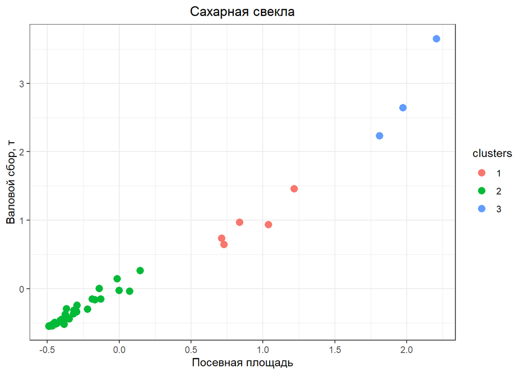

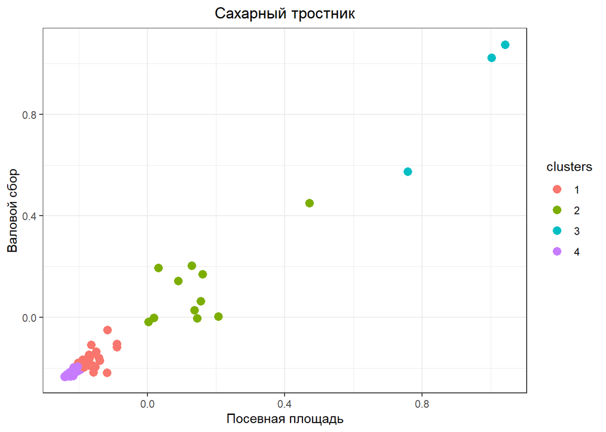

Рис. 4 результат кластеризации методом k-means

Выполним кластерный анализ методом иерархической кластеризации

Рисунок 5 отображает дендограммы, которые были построены в результате исполнения алгоритма иерархической кластеризации. В кластеризации участвовали такие показатели, как валовой сбор, площадь посевово и общая площдь с/х земель. В случае сахарной свеклы из набора данных была удалена Россия, которая мешала адекватному разбиению на кластеры. Можно заметить, что разделение объектов на кластеры имеет одну закономерность: что у сахарной свеклы, что у сахарного тростника выделяются страны-лидеры, основной массив стран и страны с наименьшими показателямми.

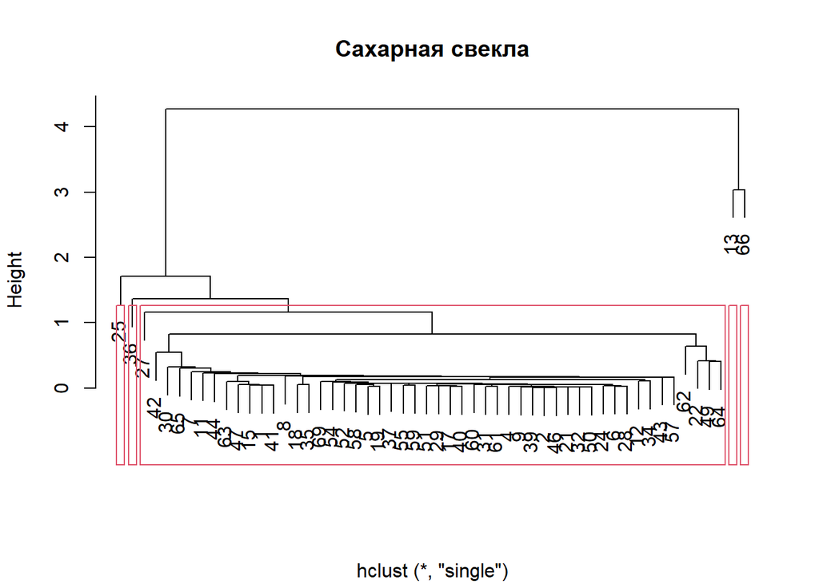

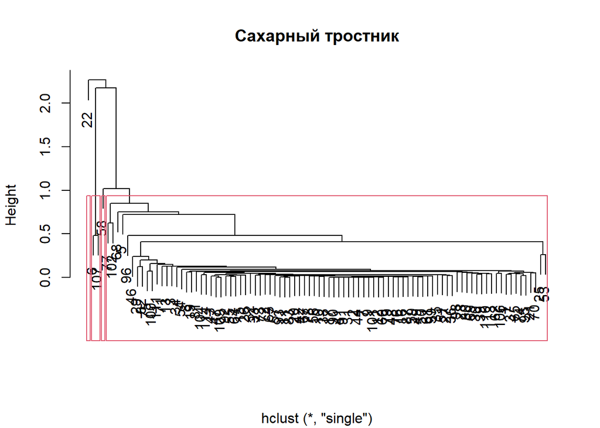

Рис. 5 результат иерархической кластеризации

#### Верификация:

Оптимальное количество кластеров можно получить на основу такого показателя, как *общая внутригрупповая сумма квадратов*. Если добавление одного кластера в наши данные значительно понижает общую сумму квадратов, то в увеличении числа кластеров есть смысл. Если при увеличении числа кластеров идет плавное снижение общей внутригрупповой суммы квадратов, то количество кластеров избыточно. На рисунке 6 видно, что оптимальное число выделяемых кластеров составляет 3-4.

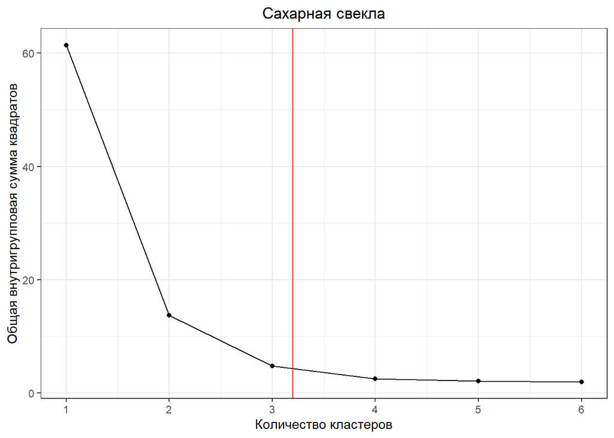

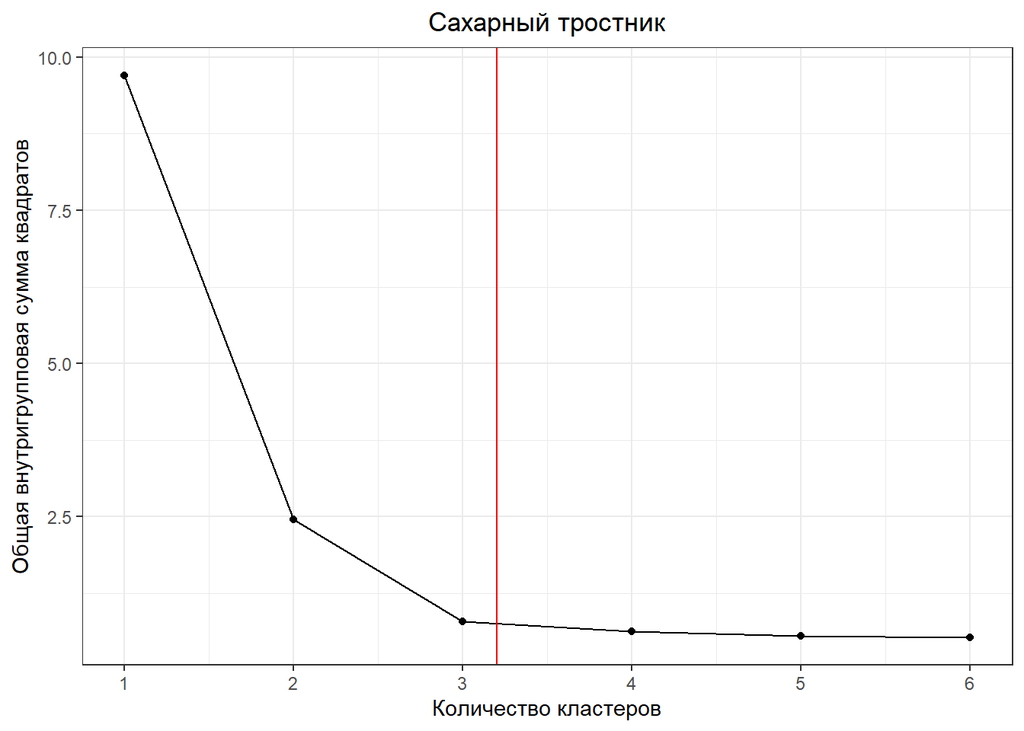

Рис. 6 оптимальное число кластеров

Таким образом нам удалось провести кластерный анализ двумя способами и подтвердить нашу гипотезу.